# Session 10: Data Science Capstone Project

Zervaan Borok

2021-12-23

# 1 Introduction and learning objectives

The purpose of this exercise is to build an estimation engine to guide investment decisions in London house market. You will first build machine learning algorithms (and tune them) to estimate the house prices given variety of information about each property. Then, using your algorithm, you will choose 200 houses to invest in out of about 2000 houses on the market at the moment.

**Learning objectives**

1. Using different data mining algorithms for prediction.
2. Dealing with large data sets
3. Tuning data mining algorithms
4. Interpreting data mining algorithms and deducing importance of variables
5. Using results of data mining algorithms to make business decisions

# 2 Load data

**There are two sets of data, i) training data that has the actual prices ii) out of sample data that has the asking prices. Load both data sets.**

```r
# Read in the data
london_house_prices_2019_training <- read.csv("C:/Users/zerva/OneDrive/Documents/R Scipts LBS/am10.mam2022/training_data_assignment_with_prices.csv")
london_house_prices_2019_out_of_sample <- read.csv("C:/Users/zerva/OneDrive/Documents/R Scipts LBS/am10.mam2022/test_data_assignment.csv")


# Fix data types in both data sets

# Fix dates
london_house_prices_2019_training <- london_house_prices_2019_training %>% mutate(date=as.Date(date))
london_house_prices_2019_out_of_sample <- london_house_prices_2019_out_of_sample %>% mutate(date=as.Date(date))

# Change characters to factors
london_house_prices_2019_training <- london_house_prices_2019_training %>% mutate_if(is.character,as.factor)
london_house_prices_2019_out_of_sample <- london_house_prices_2019_out_of_sample %>% mutate_if(is.character,as.factor)

# Take a quick look at what's in the data
str(london_house_prices_2019_training)
```

```
## 'data.frame':    13998 obs. of  37 variables:
##  $ ID                          : int  2 3 4 5 7 8 9 10 11 12 ...
##  $ date                        : Date, format: "2019-11-01" "2019-08-08" ...
##  $ postcode                    : Factor w/ 12635 levels "BR1 1AB","BR1 1LR",..: 10897 11027 11264 2031 11241 11066 421 9594 9444 873 ...
##  $ property_type               : Factor w/ 4 levels "D","F","S","T": 2 2 3 2 3 2 1 4 4 2 ...
##  $ whether_old_or_new          : Factor w/ 2 levels "N","Y": 1 1 1 1 1 1 1 1 1 1 ...
##  $ freehold_or_leasehold       : Factor w/ 2 levels "F","L": 2 2 1 2 1 2 1 1 1 2 ...
##  $ address1                    : Factor w/ 2825 levels "1","1 - 2","1 - 3",..: 2503 792 253 789 569 234 264 418 5 274 ...
##  $ address2                    : Factor w/ 434 levels "1","10","101",..: 372 NA NA NA NA NA NA NA NA NA ...
##  $ address3                    : Factor w/ 8543 levels "ABBERTON WALK",..: 6990 6821 3715 2492 4168 2879 3620 5251 6045 6892 ...
##  $ town                        : Factor w/ 133 levels "ABBEY WOOD","ACTON",..: NA NA NA 78 NA NA NA NA NA NA ...
##  $ local_aut                   : Factor w/ 69 levels "ASHFORD","BARKING",..: 36 46 24 36 24 46 65 36 36 17 ...
##  $ county                      : Factor w/ 33 levels "BARKING AND DAGENHAM",..: 22 27 18 25 18 27 5 27 32 8 ...
##  $ postcode_short              : Factor w/ 247 levels "BR1","BR2","BR3",..: 190 194 198 28 198 194 4 169 167 8 ...
##  $ current_energy_rating       : Factor w/ 6 levels "B","C","D","E",..: 4 3 3 4 3 2 4 3 4 2 ...
```

[output cut: 23 more lines]

```r
str(london_house_prices_2019_out_of_sample)
```

```
## 'data.frame':    1999 obs. of  37 variables:
##  $ ID                          : int  14434 12562 8866 10721 1057 1527 13961 12108 9363 1155 ...
##  $ date                        : Date, format: NA NA ...
##  $ postcode                    : logi  NA NA NA NA NA NA ...
##  $ property_type               : Factor w/ 4 levels "D","F","S","T": 1 2 2 3 4 3 2 3 2 4 ...
##  $ whether_old_or_new          : Factor w/ 2 levels "N","Y": 1 1 1 1 1 1 1 1 1 1 ...
##  $ freehold_or_leasehold       : Factor w/ 2 levels "F","L": 1 2 2 1 1 1 2 1 2 1 ...
##  $ address1                    : logi  NA NA NA NA NA NA ...
##  $ address2                    : logi  NA NA NA NA NA NA ...
##  $ address3                    : logi  NA NA NA NA NA NA ...
##  $ town                        : Factor w/ 54 levels "ACTON","ADDISCOMBE",..: NA NA NA NA NA NA NA NA NA NA ...
##  $ local_aut                   : logi  NA NA NA NA NA NA ...
##  $ county                      : logi  NA NA NA NA NA NA ...
##  $ postcode_short              : Factor w/ 221 levels "BR1","BR2","BR3",..: 82 50 37 52 214 150 159 115 175 126 ...
##  $ current_energy_rating       : Factor w/ 6 levels "B","C","D","E",..: 3 2 3 3 4 4 4 3 4 3 ...
```

[output cut: 23 more lines]

```r
# Let's do the initial split
library(rsample)
set.seed(100)

train_test_split <- initial_split(london_house_prices_2019_training, prop = 0.75) #training set contains 75% of the data

# Create the training dataset
train_data <- training(train_test_split)
test_data <- testing(train_test_split)
```

# 3 Visualize data

**Visualize and examine the data. What plots could be useful here? What do you learn from these visualizations?**

Boxplots, histograms, and density plots will likely be the most useful for this data set. From the visualizations below, we can see that all of the variables inspected show exigent skewness. Thus, the data should be centered and scaled before being passed to any algorithms. For linear models, we can instead try regressing our predictor variables on the log of the price.

```r
# Prevent R from displaying plot tick marks in scientific notation
options(scipen = 100)
```

```r
# Table of number of properties by London Zone
library(DT)
zones_df <- as.data.frame(table(london_house_prices_2019_training$london_zone))
names(zones_df)[names(zones_df) == "Var1"] <- "London Zone"
names(zones_df)[names(zones_df) == "Freq"] <- "Number of Properties"
zones_df <- datatable(zones_df, width = 350) %>% formatStyle('London Zone', target = 'row', backgroundColor =
                                       styleEqual(c(1,2,3,4,5,6,7), c('lightgray', 'white', 'lightgray', 'white', 'lightgray', 'white', 'lightgray')))
zones_df
```

|  | London Zone | Number of Properties |
| --- | --- | --- |
| 1 | 1 | 569 |
| 2 | 2 | 2502 |
| 3 | 3 | 3411 |
| 4 | 4 | 2922 |
| 5 | 5 | 2458 |
| 6 | 6 | 2130 |
| 7 | 7 | 6 |

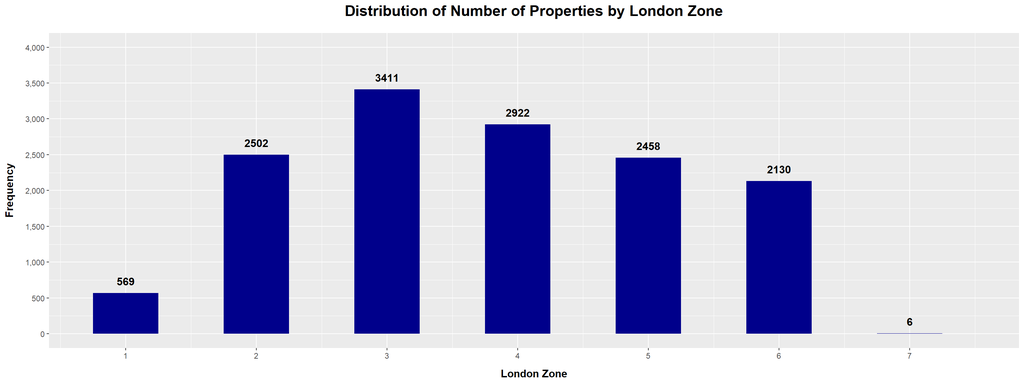

```r
# Distribution of Number of Properties by London Zone
ggplot(data = london_house_prices_2019_training, aes(x=london_zone)) +
  geom_histogram(binwidth = 0.5, fill = 'darkblue') +
    labs(title = "Distribution of Number of Properties by London Zone",
                      x = "London Zone", y = "Frequency") +
  theme(axis.title.x = element_text(margin = margin(t = 10, r = 0, b = 0, l = 0))) +
  theme(axis.title.y = element_text(margin = margin(t = 0, r = 12, b = 0, l = 0))) +
  theme(plot.title = element_text(margin = margin(t = 0, r = 0, b = 16, l = 0))) +
  theme(plot.title = element_text(hjust = 0.5)) +
  theme(plot.title = element_text(face = "bold")) +
  theme(plot.title = element_text(size = 17)) +
  theme(axis.title.x = element_text(face = "bold")) +
  theme(axis.title.x = element_text(size = 12)) +
  theme(axis.title.y = element_text(face = "bold")) +
  theme(axis.title.y = element_text(size = 12)) +
  scale_x_continuous(breaks=seq(0,7,1), limits = c(0.75,7.5)) +
  scale_y_continuous(breaks=seq(0,4000,500),limits = c(0,4000), labels = scales::comma) +
  stat_bin(aes(y=..count.. , label=..count..), geom="text", binwidth=1, vjust = -1, fontface='bold', size = 4.25)
```

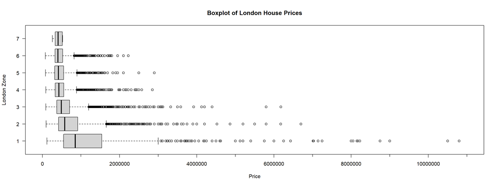

```r
library(Hmisc)

# Boxplot of House Prices by London Zone
BXplot <- boxplot(price ~ london_zone, data = london_house_prices_2019_training, horizontal = TRUE, ylim = c(0, 11000000), ylab = 'London Zone', xlab = 'Price',
                  main = 'Boxplot of London House Prices', las = 1)
minor.tick(nx = 2, ny = 0, tick.ratio = 0.75)
```

```r
# Boxplot summary statistics
library(DT)

BXplot_stats <- datatable(BXplot$stats, rownames = c("Whisker Minimum", "25th Percentile", "Median", "75th Percentile", "Whisker Maximum"),
                          colnames = c("Zone 1" = 'V1', "Zone 2" = 'V2', "Zone 3" = 'V3', "Zone 4" = 'V4', "Zone 5" = 'V5', "Zone 6" = 'V6', "Zone 7" = 'V7'))

BXplot_stats <- formatCurrency(BXplot_stats, columns = c("Zone 1", "Zone 2", "Zone 3", "Zone 4", "Zone 5", "Zone 6", "Zone 7"), currency = "£",
                               interval = 3, mark = ",", digits = 2, before = TRUE)

BXplot_stats
```

|  | Zone 1 | Zone 2 | Zone 3 | Zone 4 | Zone 5 | Zone 6 | Zone 7 |
| --- | --- | --- | --- | --- | --- | --- | --- |
| Whisker Minimum | 117500 | 96000 | 90000 | 89000 | 80000 | 77000 | 261000 |
| 25th Percentile | 550000 | 420000 | 375000 | 330000 | 318000 | 327500 | 333000 |
| Median | 850000 | 580000 | 490000 | 427277.5 | 416000 | 402250 | 408750 |
| 75th Percentile | 1540000 | 915000 | 705000 | 555000 | 550000 | 525000 | 516000 |
| Whisker Maximum | 3000000 | 1655000 | 1200000 | 885000 | 897500 | 820000 | 525000 |

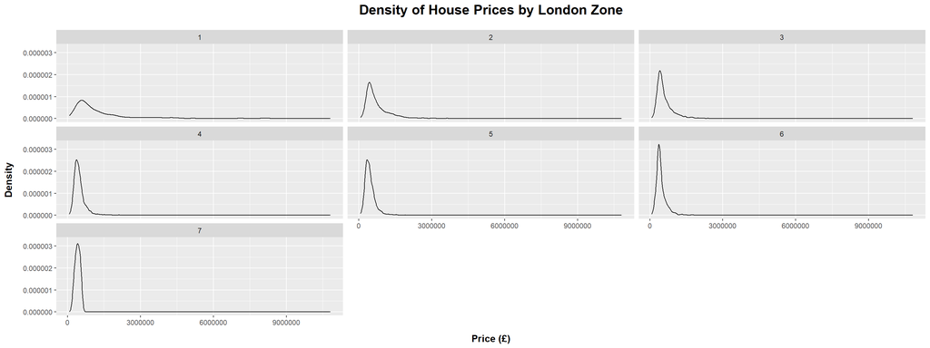

```r
# Price density by London Zone
ggplot(data = london_house_prices_2019_training, aes(x = price)) +
  geom_density() +
  labs(title = "Density of House Prices by London Zone",
                      x = "Price (£)", y = "Density") +
  theme(axis.title.x = element_text(margin = margin(t = 10, r = 0, b = 0, l = 0))) +
  theme(axis.title.y = element_text(margin = margin(t = 0, r = 12, b = 0, l = 0))) +
  theme(plot.title = element_text(margin = margin(t = 0, r = 0, b = 16, l = 0))) +
  facet_wrap(london_house_prices_2019_training$london_zone) +
  theme(plot.title = element_text(hjust = 0.5)) +
  theme(plot.title = element_text(face = "bold")) +
  theme(plot.title = element_text(size = 17)) +
  theme(axis.title.x = element_text(face = "bold")) +
  theme(axis.title.x = element_text(size = 12)) +
  theme(axis.title.y = element_text(face = "bold")) +
  theme(axis.title.y = element_text(size = 12))
```

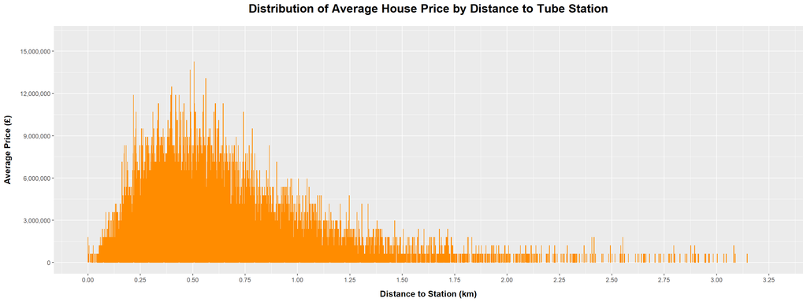

```r
# Average price by Distance to Station
ggplot(data = london_house_prices_2019_training, aes(x = distance_to_station, y = mean(price))) +
  geom_col(color = 'darkorange') +
  labs(title = "Distribution of Average House Price by Distance to Tube Station",
                      x = "Distance to Station (km)", y = "Average Price (£)") +
  theme(axis.title.x = element_text(margin = margin(t = 10, r = 0, b = 0, l = 0))) +
  theme(axis.title.y = element_text(margin = margin(t = 0, r = 12, b = 0, l = 0))) +
  theme(plot.title = element_text(margin = margin(t = 0, r = 0, b = 16, l = 0))) +
  theme(plot.title = element_text(hjust = 0.5)) +
  theme(plot.title = element_text(face = "bold")) +
  theme(plot.title = element_text(size = 17)) +
  theme(axis.title.x = element_text(face = "bold")) +
  theme(axis.title.x = element_text(size = 12)) +
  theme(axis.title.y = element_text(face = "bold")) +
  theme(axis.title.y = element_text(size = 12) )+
  scale_x_continuous(breaks=seq(0,4,0.25), limits = c(0,3.25)) +
  scale_y_continuous(breaks=seq(0,16000000,3000000), labels = scales::comma, limits = c(0,16000000))
```

```r
# Table of number of properties by number of habitable rooms
rooms_df <- as.data.frame(table(london_house_prices_2019_training$number_habitable_rooms))
names(rooms_df)[names(rooms_df) == "Var1"] <- "Number of Habitable Rooms"
names(rooms_df)[names(rooms_df) == "Freq"] <- "Number of Properties"
rooms_df <- datatable(rooms_df, height = 800, width = 350) %>% formatStyle('Number of Habitable Rooms', target = 'row', backgroundColor =
                                       styleEqual(c(1,2,3,4,5,6,7,8,9,10,11,12,13,14), c('lightgray', 'white', 'lightgray', 'white', 'lightgray', 'white', 'lightgray', 'white', 'lightgray', 'white', 'lightgray', 'white', 'lightgray', 'white')))
rooms_df
```

|  | Number of Habitable Rooms | Number of Properties |
| --- | --- | --- |
| 1 | 1 | 134 |
| 2 | 2 | 1476 |
| 3 | 3 | 3486 |
| 4 | 4 | 2988 |
| 5 | 5 | 3007 |
| 6 | 6 | 1528 |
| 7 | 7 | 816 |
| 8 | 8 | 353 |
| 9 | 9 | 118 |
| 10 | 10 | 56 |

[output cut: 4 more lines]

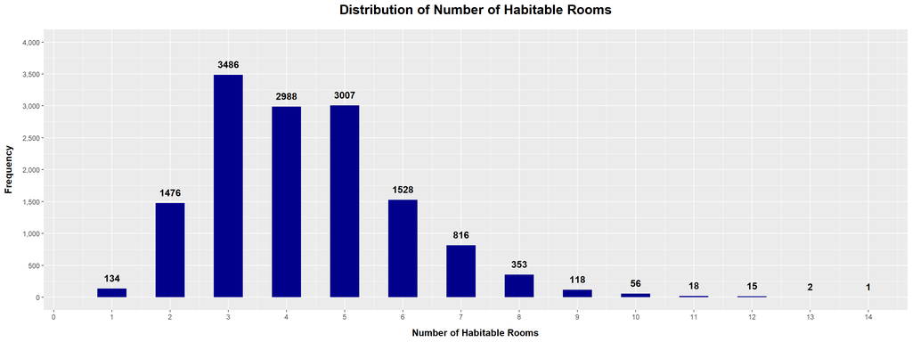

```r
# Distribution of Number of Habitable Rooms
ggplot(data = london_house_prices_2019_training, aes(x=number_habitable_rooms)) +
  geom_histogram(binwidth = 0.5, fill = 'darkblue') +
    labs(title = "Distribution of Number of Habitable Rooms",
                      x = "Number of Habitable Rooms", y = "Frequency") +
  theme(axis.title.x = element_text(margin = margin(t = 10, r = 0, b = 0, l = 0))) +
  theme(axis.title.y = element_text(margin = margin(t = 0, r = 12, b = 0, l = 0))) +
  theme(plot.title = element_text(margin = margin(t = 0, r = 0, b = 16, l = 0))) +
  theme(plot.title = element_text(hjust = 0.5)) +
  theme(plot.title = element_text(face = "bold")) +
  theme(plot.title = element_text(size = 17)) +
  theme(axis.title.x = element_text(face = "bold")) +
  theme(axis.title.x = element_text(size = 12)) +
  theme(axis.title.y = element_text(face = "bold")) +
  theme(axis.title.y = element_text(size = 12)) +
  scale_x_continuous(breaks=seq(0,14,1), limits = c(0.5,14)) +
  scale_y_continuous(breaks=seq(0,4000,500),limits = c(0,4000), labels = scales::comma) +
  stat_bin(aes(y=..count.. , label=..count..), geom="text", binwidth=1, vjust = -1, fontface='bold', size = 4.25)
```

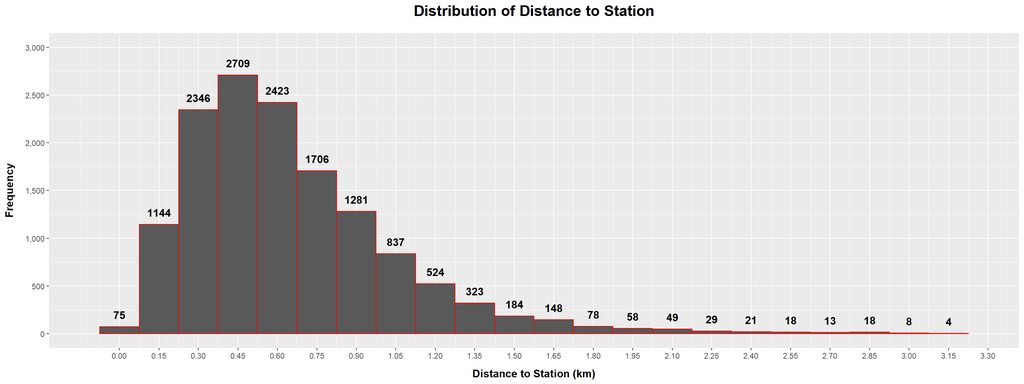

```r
# Distribution of Distance to Station
ggplot(data = london_house_prices_2019_training, aes(x=distance_to_station)) +
  geom_histogram(binwidth = 0.15, color = 'red') +
    labs(title = "Distribution of Distance to Station",
                      x = "Distance to Station (km)", y = "Frequency") +
  theme(axis.title.x = element_text(margin = margin(t = 10, r = 0, b = 0, l = 0))) +
  theme(axis.title.y = element_text(margin = margin(t = 0, r = 12, b = 0, l = 0))) +
  theme(plot.title = element_text(margin = margin(t = 0, r = 0, b = 16, l = 0))) +
  theme(plot.title = element_text(hjust = 0.5)) +
  theme(plot.title = element_text(face = "bold")) +
  theme(plot.title = element_text(size = 17)) +
  theme(axis.title.x = element_text(face = "bold")) +
  theme(axis.title.x = element_text(size = 12)) +
  theme(axis.title.y = element_text(face = "bold")) +
  theme(axis.title.y = element_text(size = 12)) +
  scale_x_continuous(breaks=seq(0,4,0.15), limits = c(-0.1,3.25)) +
  scale_y_continuous(breaks=seq(0,3000,500),limits = c(0,3000), labels = scales::comma) +
  stat_bin(aes(y=..count.. , label=..count..), geom="text", binwidth=0.15, vjust = -1, fontface='bold', size = 4.25)
```

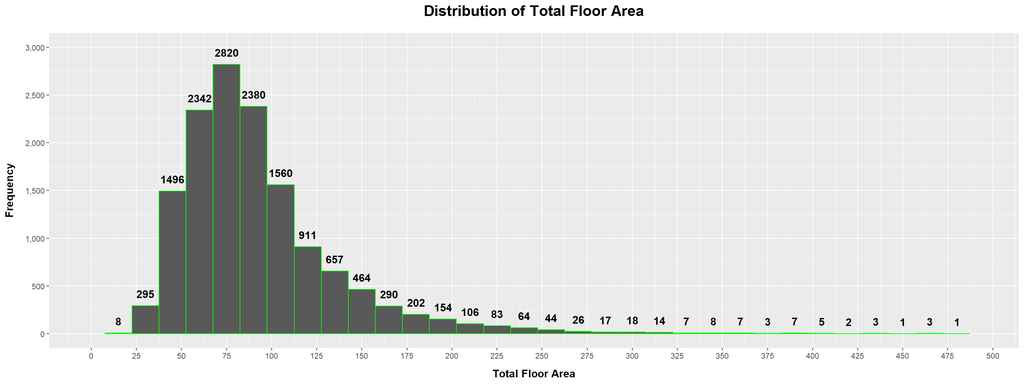

```r
# Distribution of Floor Area
ggplot(data = london_house_prices_2019_training, aes(x = total_floor_area)) +
  geom_histogram(binwidth=15, color = 'green') +
    labs(title = "Distribution of Total Floor Area",
                      x = "Total Floor Area", y = "Frequency") +
  theme(axis.title.x = element_text(margin = margin(t = 10, r = 0, b = 0, l = 0))) +
  theme(axis.title.y = element_text(margin = margin(t = 0, r = 12, b = 0, l = 0))) +
  theme(plot.title = element_text(margin = margin(t = 0, r = 0, b = 16, l = 0))) +
  theme(plot.title = element_text(hjust = 0.5)) +
  theme(plot.title = element_text(face = "bold")) +
  theme(plot.title = element_text(size = 17)) +
  theme(axis.title.x = element_text(face = "bold")) +
  theme(axis.title.x = element_text(size = 12)) +
  theme(axis.title.y = element_text(face = "bold")) +
  theme(axis.title.y = element_text(size = 12)) +
  scale_x_continuous(breaks=seq(0,500,25), limits = c(1,490)) +
  scale_y_continuous(breaks=seq(0,3000,500),limits = c(0,3000), labels = scales::comma) +
  stat_bin(aes(y=..count.. , label=..count..), geom="text", binwidth=15, vjust = -1, fontface='bold', size = 4.25)
```

**Estimate a correlation table between prices and other continuous variables. What do you glean from the correlation table?**

For the most part, the variables within this data set are mildly to moderately correlated. A few are strongly correlated, such as ‘number_habitable_rooms’ and ‘total_floor_area’, but there are no correlations with an absolute correlation coefficient magnitude greater than 0.85.

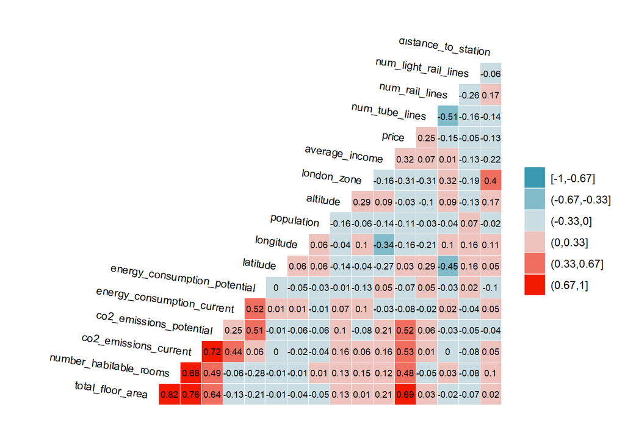

```r
library("GGally")

# Correlation Plot
london_house_prices_2019_training %>%
  select(-ID) %>% #keep Y variable last
  ggcorr(method = c("pairwise", "pearson"), layout.exp = 6,label_round=2, label = TRUE,label_size = 2.5,hjust = 1,nbreaks = 6,angle = -8, size = 3)
```

```r
# Remove unnecessary columns for Lasso
train_data_2 <- train_data[c(-1,-2,-3,-7,-8,-9,-10)]
train_data_2 <- na.omit(train_data_2)
```

```r
# Assign response and explanatory variables
y <- log(train_data_2$price)

x <- data.matrix(train_data_2[, c('property_type', 'whether_old_or_new', 'freehold_or_leasehold', 'local_aut', 'county', 'postcode_short',
                                  'current_energy_rating', 'total_floor_area', 'number_habitable_rooms', 'co2_emissions_current', 'co2_emissions_potential', 'energy_consumption_current', 'energy_consumption_potential', 'windows_energy_eff', 'tenure', 'latitude', 'longitude', 'population', 'altitude', 'london_zone', 'nearest_station', 'water_company', 'average_income', 'district', 'type_of_closest_station', 'num_tube_lines', 'num_rail_lines', 'num_light_rail_lines', 'distance_to_station')])
```

```r
# Lasso regression for variable importance
library(glmnet)

# Perform k-fold cross-validation to find optimal lambda value
lasso_model <- cv.glmnet(x, y, alpha = 1)

# Find optimal lambda value that minimizes test MSE
best_lambda <- lasso_model$lambda.min
best_lambda
```

```
## [1] 0.0002831494
```

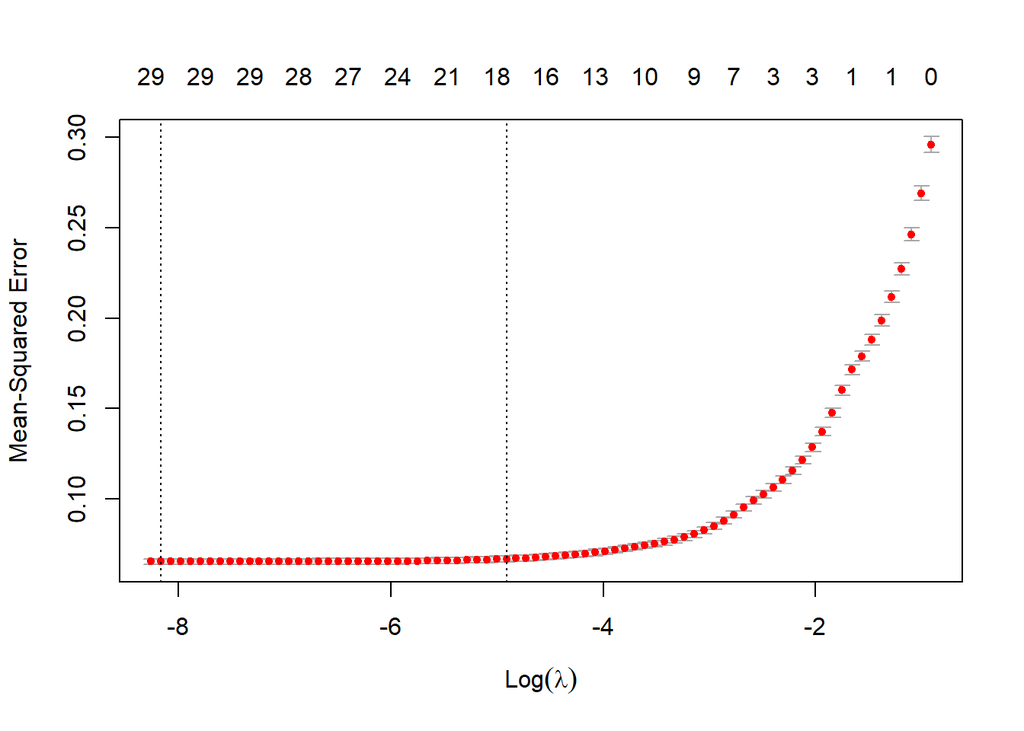

```r
plot(lasso_model)
```

```r
# Find coefficients of best model
best_model <- glmnet(x, y, alpha = 1, lambda = best_lambda)
coef(best_model)
```

```
## 30 x 1 sparse Matrix of class "dgCMatrix"
##                                           s0
## (Intercept)                  -26.72672284535
## property_type                 -0.02346918522
## whether_old_or_new             0.17336823473
## freehold_or_leasehold         -0.26927139044
## local_aut                      0.00014646398
## county                        -0.00107826491
## postcode_short                 0.00050791536
## current_energy_rating          0.04758555273
## total_floor_area               0.00535001570
## number_habitable_rooms         0.00848429087
## co2_emissions_current         -0.00595737188
## co2_emissions_potential        0.05059726997
## energy_consumption_current    -0.00037086415
## energy_consumption_potential  -0.00060650855
## windows_energy_eff             0.03643631026
## tenure                        -0.03414619971
## latitude                       0.75526464590
## longitude                     -0.24768483649
## population                    -0.00054110812
## altitude                       0.00016172404
## london_zone                   -0.09936679926
## nearest_station                0.00002345783
## water_company                  0.03685428488
## average_income                 0.00001389968
## district                       0.00121290014
## type_of_closest_station       -0.01631481821
## num_tube_lines                 0.08843811357
## num_rail_lines                 0.01526560905
## num_light_rail_lines           0.00436258695
## distance_to_station           -0.01636838664
```

```r
# Use fitted best model to make predictions
y_predicted <- predict(best_model, s = best_lambda, newx = x)
y_predicted <- y_predicted

# Find SST and SSE
sst <- sum((y - mean(y))^2)
sse <- sum((y_predicted - y)^2)

# Find R-Squared
rsq <- 1 - sse/sst
rsq
```

```
## [1] 0.7808445
```

# 4 Fit a linear regression model

```r
# Define control variables
control <- trainControl (
    method="cv",
    number=10,
    verboseIter=TRUE) #by setting this to true the model will report its progress after each estimation

# We are going to train the model and report the results using k-fold cross validation
model1_lm<-train(
    log(price) ~ distance_to_station + property_type + longitude + total_floor_area + number_habitable_rooms
       + london_zone + type_of_closest_station + num_tube_lines + num_light_rail_lines + average_income + district + windows_energy_eff + co2_emissions_potential + co2_emissions_current + energy_consumption_potential,
    train_data,
   method = "lm",
    trControl = control
   )
# Summary of the results
summary(model1_lm)
```

```
##
## Call:
## lm(formula = .outcome ~ ., data = dat)
##
## Residuals:
##      Min       1Q   Median       3Q      Max
## -1.65115 -0.11440  0.01042  0.13451  1.44255
##
## Coefficients:
##                                       Estimate    Std. Error t value
## (Intercept)                      12.1914866607  0.0392530076 310.587
## distance_to_station              -0.0327615953  0.0065403341  -5.009
## property_typeF                   -0.3542415407  0.0135715052 -26.102
## property_typeS                   -0.0612963469  0.0115401744  -5.312
## property_typeT                   -0.1071159586  0.0116477693  -9.196
## longitude                         0.2143213552  0.0725854680   2.953
## total_floor_area                  0.0048613904  0.0001408149  34.523
## number_habitable_rooms            0.0173232756  0.0028988801   5.976
## london_zone                      -0.0861284443  0.0032978942 -26.116
## type_of_closest_stationrail      -0.0368738627  0.0149019949  -2.474
## type_of_closest_stationtube      -0.0223435385  0.0160903999  -1.389
## num_tube_lines                    0.0259530468  0.0066820222   3.884
## num_light_rail_lines             -0.0258011556  0.0132733302  -1.944
## average_income                    0.0000129464  0.0000003521  36.764
## districtBarnet                    0.2829531231  0.0318759629   8.877
## districtBexley                    0.0399143314  0.0210660684   1.895
## districtBrent                     0.3108159795  0.0368273658   8.440
## districtBromley                   0.1286382740  0.0217147570   5.924
## districtCamden                    0.5309833788  0.0325297319  16.323
## `districtCity of London`          0.6215801755  0.1104012304   5.630
## districtCroydon                   0.0661381014  0.0262043057   2.524
## districtEaling                    0.2788631198  0.0399420564   6.982
## districtEnfield                   0.2417508291  0.0262295841   9.217
## districtGreenwich                 0.0852124625  0.0226988451   3.754
## districtHackney                   0.4089338728  0.0289305099  14.135
## `districtHammersmith and Fulham`  0.5364766486  0.0374337494  14.331
## districtHaringey                  0.3553988065  0.0305300767  11.641
## districtHarrow                    0.2660076554  0.0429475028   6.194
## districtHavering                  0.1366425726  0.0215120058   6.352
## districtHillingdon                0.2937400754  0.0456104115   6.440
```

[output cut: 68 more lines]

```
## districtWandsworth               < 0.0000000000000002 ***
## districtWestminster              < 0.0000000000000002 ***
## windows_energy_effGood                       0.005330 **
## windows_energy_effPoor           < 0.0000000000000002 ***
## `windows_energy_effVery Good`                0.292827
## `windows_energy_effVery Poor`    < 0.0000000000000002 ***
## co2_emissions_potential          < 0.0000000000000002 ***
## co2_emissions_current                        0.020883 *
## energy_consumption_potential     < 0.0000000000000002 ***
## ---
## Signif. codes:  0 '***' 0.001 '**' 0.01 '*' 0.05 '.' 0.1 ' ' 1
##
## Residual standard error: 0.2369 on 10445 degrees of freedom
## Multiple R-squared:  0.8119, Adjusted R-squared:  0.8109
## F-statistic: 866.9 on 52 and 10445 DF,  p-value: < 0.00000000000000022
```

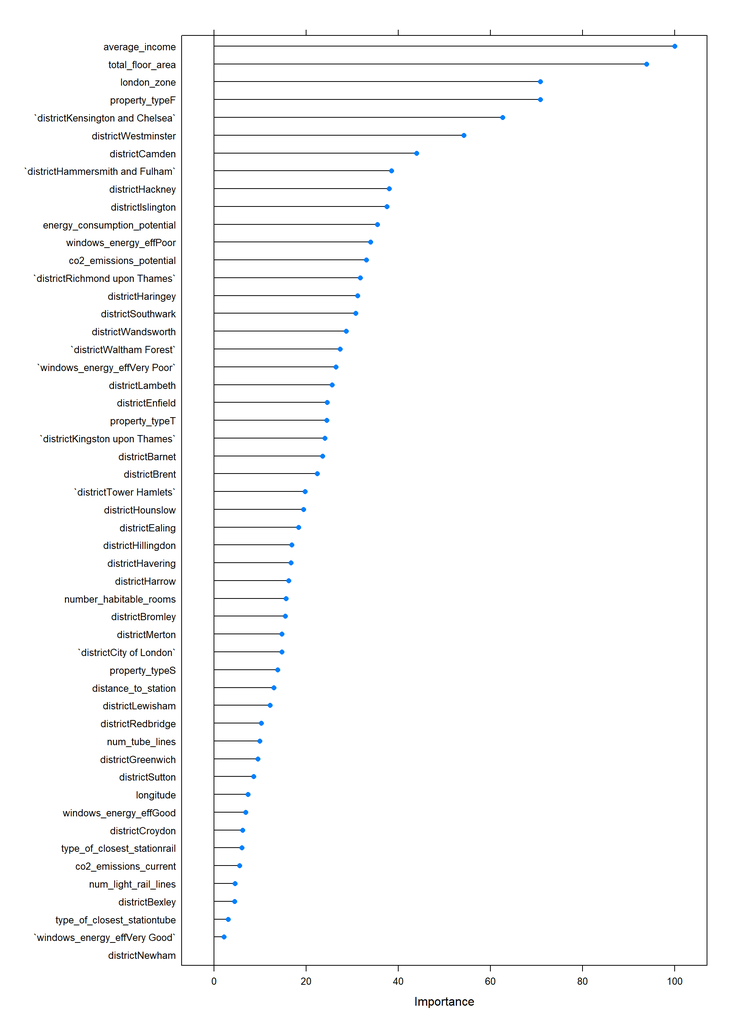

```r
# Check variable importance as well
importance_lm <- varImp(model1_lm, scale=TRUE)
plot(importance_lm)
```

```r
# List definitions of variables
df_vars <- data.frame(Variable  = c("distance to station", "property type", "longitude", "total floor area", "number habitable rooms", "london zone", "type of closest station", "num tube lines", "num light rail lines", "average income", "district", "windows energy eff", "co2 emissions potential", "co2 emissions current", "energy consumption potential"),
                  Definition = c("The distance in kilometers to the nearest station from the postcode", "D = Detached, S = Semi-Detached, T = Terraced, F = Flats/Maisonettes, O = Other", "Longitude of centroid of the Postcode in decimal format", "Total of all enclosed spaces measured to the internal face of the external walls in square meters", "Habitable rooms include any living room, sitting room, dining room, bedroom, study and similar", "Transport for London (TFL) Travel Zone Indicator", "The type of closest train station (i.e. tube, DLR, or overground)", "Number of tube lines that use the closest station", "Number of light rail lines that use the closest station", "Average household income of the MSOA that the postcode is located in", "The district the property is in (i.e. Kensington, Chelsea, etc)", "Energy efficiency rating of windows with values of very poor, poor, average, good, very good", "Estimated value in Tonnes per Year of the total CO2 emissions produced by the property in 12 month period", "CO2 emissions per year in tonnes/year", "Estimated potential total energy consumption for the property in a 12 month in kilowatt hours per square meter")
                  )
df_vars
```

```
##                        Variable
## 1           distance to station
## 2                 property type
## 3                     longitude
## 4              total floor area
## 5        number habitable rooms
## 6                   london zone
## 7       type of closest station
## 8                num tube lines
## 9          num light rail lines
## 10               average income
## 11                     district
## 12           windows energy eff
## 13      co2 emissions potential
## 14        co2 emissions current
```

[output cut: 17 more lines]

## 4.1 Predict the values in testing and out of sample data

**Below I use the predict function to test the performance of the model in testing data and summarize the performance of the linear regression model. How can you measure the quality of your predictions?**

```r
# Predict the testing values
predictions <- predict(model1_lm,test_data)

lr_results<-data.frame(  RMSE = RMSE(exp(predictions), test_data$price),
                            Rsquare = R2(exp(predictions), test_data$price))


lr_results
```

```
##       RMSE   Rsquare
## 1 273054.3 0.7554537
```

```r
# Predict prices for out of sample data the same way
predictions_oos <- predict(model1_lm,london_house_prices_2019_out_of_sample)

lr_pred<-data.frame(  RMSE = RMSE(exp(predictions_oos), london_house_prices_2019_out_of_sample$asking_price),
                            Rsquare = R2(exp(predictions_oos), london_house_prices_2019_out_of_sample$asking_price))

lr_pred
```

```
##     RMSE   Rsquare
## 1 277399 0.8365919
```

# 5 Fit a tree model

**Compare the performance of the linear regression model with the tree model; which one performs better? Why do you think that is the case?**

```r
# Construct Tree Model
model2_tree <- train(
  price ~ distance_to_station + property_type + longitude + total_floor_area + number_habitable_rooms
       + london_zone + type_of_closest_station + num_tube_lines + num_light_rail_lines + average_income + district + windows_energy_eff + co2_emissions_potential + co2_emissions_current + energy_consumption_potential,
  train_data,
  method = "rpart",
  trControl = control,
  tuneLength=35,
  preProcess = c("center", "scale")
    )
# View how the tree performs
model2_tree$results
```

```
##             cp     RMSE  Rsquared      MAE   RMSESD RsquaredSD     MAESD
## 1  0.001294721 277570.1 0.7116217 140626.9 42743.65 0.06781525  6436.217
## 2  0.001527032 277774.2 0.7115423 141843.6 41241.40 0.06185860  5989.057
## 3  0.001546282 277698.5 0.7118412 141864.3 41346.05 0.06210361  5974.147
## 4  0.001968489 279189.5 0.7077455 144356.8 40471.52 0.06323123  5796.198
## 5  0.002077921 280292.6 0.7052824 145462.3 41421.52 0.06245809  6408.102
## 6  0.002078280 280292.6 0.7052824 145462.3 41421.52 0.06245809  6408.102
## 7  0.002126708 281056.9 0.7038997 146205.9 41844.83 0.06291776  6608.041
## 8  0.002244042 282712.0 0.7000921 146941.4 41525.38 0.06336091  6291.217
## 9  0.002279582 283415.6 0.6986588 147186.2 41267.10 0.06171601  6129.913
## 10 0.002482884 284301.7 0.6963578 147807.9 41499.65 0.06194408  6155.323
## 11 0.002552165 284863.0 0.6951304 148218.2 41714.18 0.06231883  6440.942
## 12 0.002577695 284863.0 0.6951304 148218.2 41714.18 0.06231883  6440.942
## 13 0.002829361 285108.7 0.6939907 148574.1 42054.06 0.06201134  6261.098
## 14 0.002941085 286090.4 0.6922274 149001.7 41838.06 0.06222610  6391.934
```

[output cut: 21 more lines]

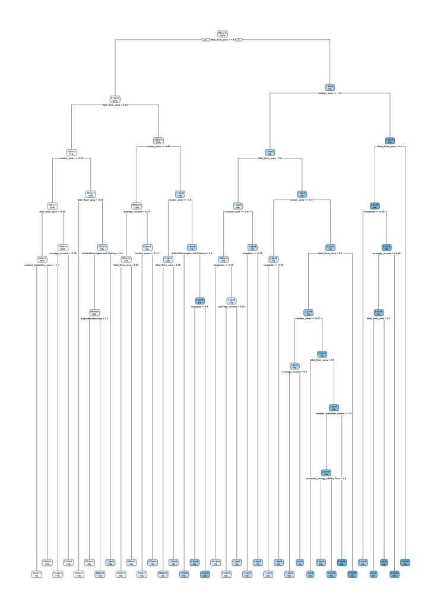

```r
# View the final tree
rpart.plot(model2_tree$finalModel)
```

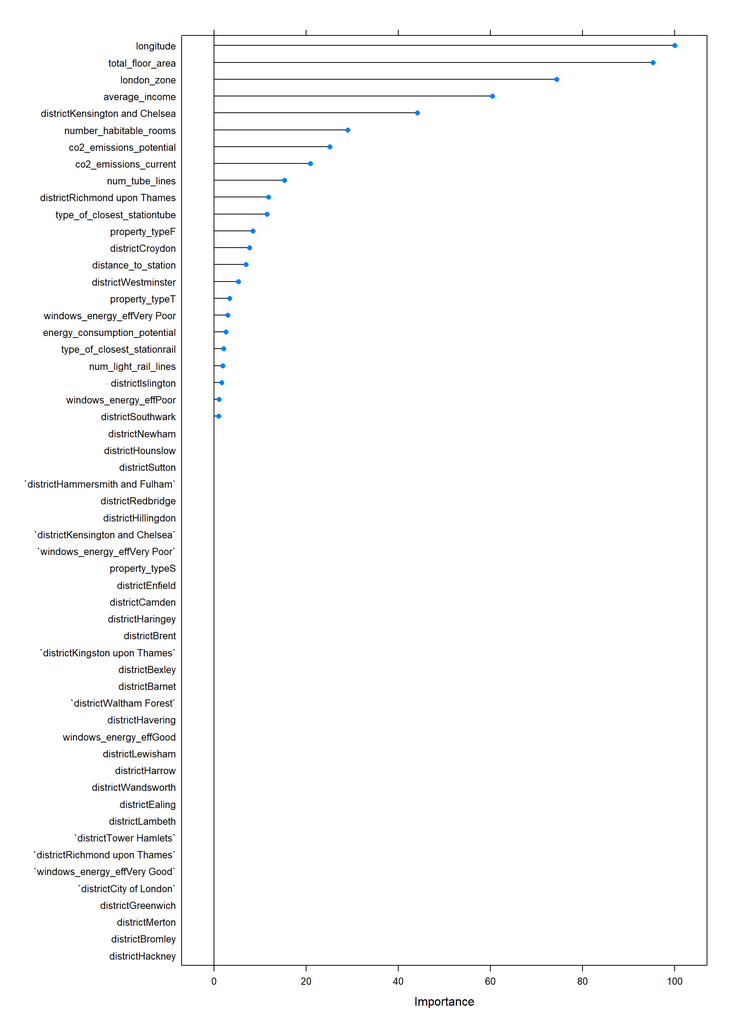

```r
# Visualize the variable importance
importance_tree <- varImp(model2_tree, scale=TRUE)
plot(importance_tree)
```

```r
# Predict the testing values
predictions_tree <- predict(model2_tree,test_data)

tree_results<-data.frame(  RMSE = RMSE(predictions_tree, test_data$price),
                            Rsquare = R2(predictions_tree, test_data$price))


tree_results
```

```
##       RMSE   Rsquare
## 1 242886.2 0.7963774
```

```r
# Predict prices for out of sample data the same way
predictions_oos_tree <- predict(model2_tree,london_house_prices_2019_out_of_sample)

tree_pred<-data.frame(  RMSE = RMSE(predictions_oos_tree, london_house_prices_2019_out_of_sample$asking_price),
                            Rsquare = R2(predictions_oos_tree, london_house_prices_2019_out_of_sample$asking_price))

tree_pred
```

```
##       RMSE   Rsquare
## 1 353176.9 0.7570202
```

# 6 Other algorithms

**Use at least two other algorithms to predict prices. Don’t forget to tune the parameters of these algorithms. And then compare the performances of your algorithms to linear regression and trees.**

```r
set.seed(100)
# KNN Model
knn_fit <- train(log(price) ~ distance_to_station + property_type + longitude + total_floor_area + number_habitable_rooms
       + london_zone + type_of_closest_station + num_tube_lines + num_light_rail_lines + average_income + district + windows_energy_eff + co2_emissions_potential + co2_emissions_current + energy_consumption_potential, data= train_data,
                 method = "knn",
                 trControl = trainControl("cv", number = 10), #use cross validation with 10 data points
                 tuneLength = 10, #number of parameter values train function will try
                 preProcess = c("center", "scale"))  #center and scale the data

knn_fit
```

```
## k-Nearest Neighbors
##
## 10498 samples
##    15 predictor
##
## Pre-processing: centered (52), scaled (52)
## Resampling: Cross-Validated (10 fold)
## Summary of sample sizes: 9448, 9448, 9448, 9448, 9448, 9449, ...
## Resampling results across tuning parameters:
##
##   k   RMSE       Rsquared   MAE
##    5  0.2762733  0.7444287  0.1996109
##    7  0.2758991  0.7476862  0.1990509
##    9  0.2766614  0.7489267  0.1995354
##   11  0.2781225  0.7485872  0.2008731
##   13  0.2804806  0.7467986  0.2028242
##   15  0.2827298  0.7447577  0.2043543
##   17  0.2851164  0.7423832  0.2062618
##   19  0.2864791  0.7413473  0.2074438
##   21  0.2879978  0.7403097  0.2088322
##   23  0.2901937  0.7379655  0.2105760
##
## RMSE was used to select the optimal model using the smallest value.
## The final value used for the model was k = 7.
```

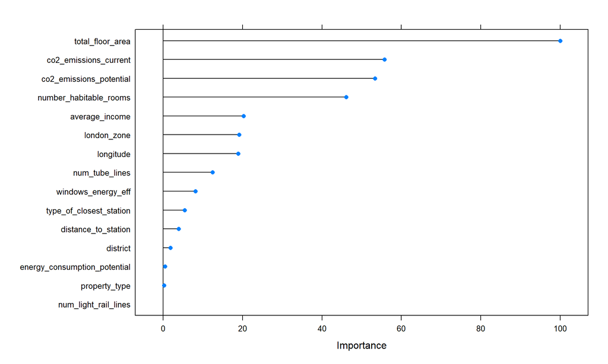

```r
# Check variable importance
importance_knn <- varImp(knn_fit, scale=TRUE)
plot(importance_knn)
```

```r
# Predict the testing values
predictions_knn <- predict(knn_fit,test_data)
predictions_knn <- exp(predictions_knn)

knn_results<-data.frame(  RMSE = RMSE(predictions_knn, test_data$price),
                            Rsquare = R2(predictions_knn, test_data$price))

knn_results
```

```
##     RMSE   Rsquare
## 1 273568 0.7942476
```

```r
# Predict prices for out of sample data the same way
predictions_oos_knn <- predict(knn_fit,london_house_prices_2019_out_of_sample)
predictions_oos_knn <- exp(predictions_oos_knn)

knn_pred<-data.frame(  RMSE = RMSE(predictions_oos_knn, london_house_prices_2019_out_of_sample$asking_price),
                            Rsquare = R2(predictions_oos_knn, london_house_prices_2019_out_of_sample$asking_price))

knn_pred
```

```
##       RMSE   Rsquare
## 1 337737.7 0.8019112
```

```r
# Optimal Value for k
optimal_k <- knn_fit$bestTune
optimal_k <- optimal_k[,1]
optimal_k
```

```
## [1] 7
```

```r
set.seed(100)
# Random Forest Model
rf_fit <- train(log(price) ~ distance_to_station + property_type + longitude + total_floor_area + number_habitable_rooms
       + london_zone + type_of_closest_station + num_tube_lines + num_light_rail_lines + average_income + district + windows_energy_eff + co2_emissions_potential + co2_emissions_current + energy_consumption_potential, data= train_data,
                 method = "ranger",
                 metric = "Rsquared",
                 trControl = control,
                 tuneLength = 10,
                # tuneGrid = grid,
                 preProcess = c("center", "scale"),
                 importance = 'permutation',
                 verbose = FALSE
                 )
```

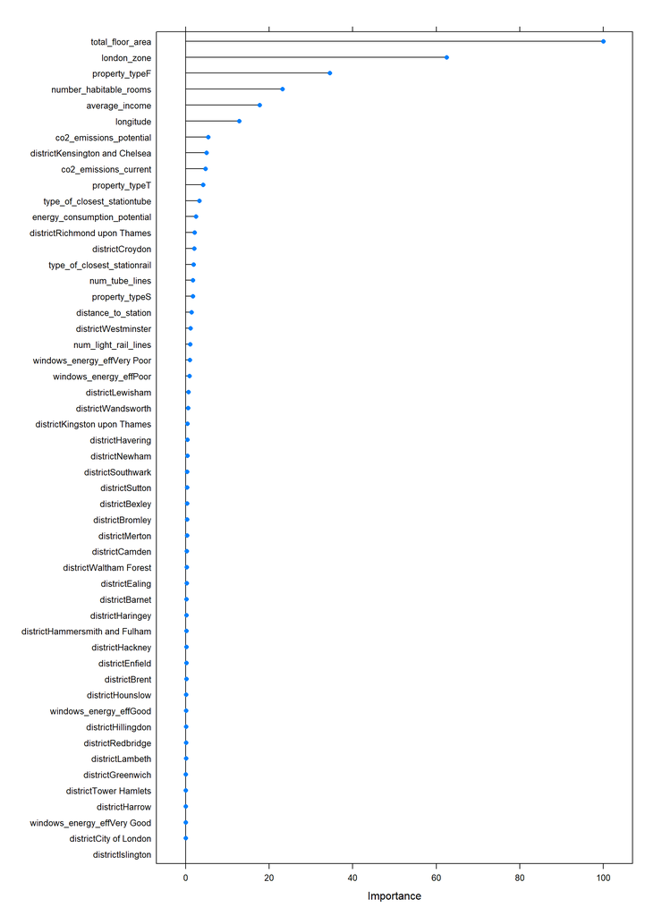

```r
# Check variable importance as well
importance_rf <- varImp(rf_fit, scale=TRUE)
plot(importance_rf)
```

```r
# Predict the testing values
predictions_rf <- predict(rf_fit,test_data)
predictions_rf <- exp(predictions_rf)

rf_results<-data.frame(  RMSE = RMSE(predictions_rf, test_data$price),
                            Rsquare = R2(predictions_rf, test_data$price))

rf_results
```

```
##       RMSE   Rsquare
## 1 213409.5 0.8740774
```

```r
# Predict prices for out of sample data the same way
predictions_oos_rf <- predict(rf_fit,london_house_prices_2019_out_of_sample)
predictions_oos_rf <- exp(predictions_oos_rf)

rf_pred<-data.frame(  RMSE = RMSE(predictions_oos_rf, london_house_prices_2019_out_of_sample$asking_price),
                            Rsquare = R2(predictions_oos_rf, london_house_prices_2019_out_of_sample$asking_price))

rf_pred
```

```
##       RMSE   Rsquare
## 1 338038.9 0.8021586
```

```r
# Optimal Parameters for Random Forest
rf_params <- rf_fit$bestTune
rf_params
```

```
##    mtry  splitrule min.node.size
## 12   29 extratrees             5
```

```r
optimal_mtry <- rf_params[,1]
optimal_mim_node_size <- rf_params[,3]
```

```r
# Give definitions of parameters
df_rf_params <- data.frame(Parameter = c("mtry", "splitrule", "minimum.node.size"), Definition = c("Number of randomly chosen variables to do a split each time", "Purity measure", "Minimum size allowed for a leaf"))

df_rf_params
```

```
##           Parameter                                                  Definition
## 1              mtry Number of randomly chosen variables to do a split each time
## 2         splitrule                                              Purity measure
## 3 minimum.node.size                             Minimum size allowed for a leaf
```

```r
set.seed(100)
# GBM Model
library(gbm)

grid <- expand.grid(interaction.depth = 6,n.trees = 150,shrinkage =0.075, n.minobsinnode = 10)

gbm_fit <- train(log(price) ~ distance_to_station + property_type + longitude + total_floor_area + number_habitable_rooms
       + london_zone + type_of_closest_station + num_tube_lines + num_light_rail_lines + average_income + district + windows_energy_eff + co2_emissions_potential + co2_emissions_current + energy_consumption_potential, data= train_data,
                 method = "gbm",
                 trControl = control,
                 tuneLength = 35,
                 preProcess = c("center", "scale"),
                 tuneGrid = grid,
                 verbose = FALSE
                 )
# Give definition of parameters
df_gbm_params <- data.frame(Parameter = c("n.trees", "interaction.depth", "shrinkage", "n.minobsinnode’"), Definition = c("Number of iterations", "Complexity of tree", "Learning rate, i.e. how quickly the algorithm adapts", "The minimum number of training set samples in a node to stop splitting"))

df_gbm_params
```

```
##           Parameter
## 1           n.trees
## 2 interaction.depth
## 3         shrinkage
## 4   n.minobsinnode’
##                                                               Definition
## 1                                                   Number of iterations
## 2                                                     Complexity of tree
## 3                   Learning rate, i.e. how quickly the algorithm adapts
## 4 The minimum number of training set samples in a node to stop splitting
```

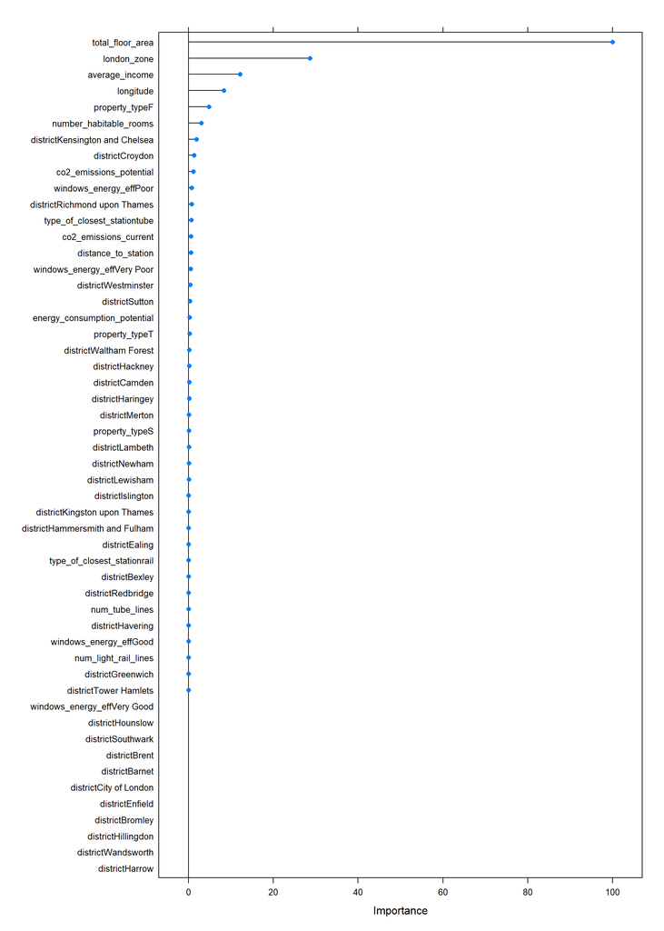

```r
# Check variable importance
importance_gbm <- varImp(gbm_fit, scale=TRUE)
plot(importance_gbm)
```

```r
# Predict the testing values
predictions_gbm <- predict(gbm_fit,test_data)
predictions_gbm <- exp(predictions_gbm)

gbm_results<-data.frame(  RMSE = RMSE(predictions_gbm, test_data$price),
                            Rsquare = R2(predictions_gbm, test_data$price))

gbm_results
```

```
##       RMSE   Rsquare
## 1 214256.9 0.8557589
```

```r
# Predict prices for out of sample data the same way
predictions_oos_gbm <- predict(gbm_fit,london_house_prices_2019_out_of_sample)
predictions_oos_gbm <- exp(predictions_oos_gbm)

gbm_pred<-data.frame(  RMSE = RMSE(predictions_oos_gbm, london_house_prices_2019_out_of_sample$asking_price),
                            Rsquare = R2(predictions_oos_gbm, london_house_prices_2019_out_of_sample$asking_price))

gbm_pred
```

```
##       RMSE   Rsquare
## 1 318024.4 0.8161633
```

# 7 Stacking

Use stacking to ensemble your algorithms.

```r
library(caret)
```

```r
set.seed(100)
# Ensemble Model
  model_list_1 <- caretList(
    log(price) ~ distance_to_station + property_type + longitude + total_floor_area + number_habitable_rooms
       + london_zone + type_of_closest_station + num_tube_lines + num_light_rail_lines + average_income + district + windows_energy_eff + co2_emissions_potential + co2_emissions_current + energy_consumption_potential, data = train_data,
    trControl=control,
    metric = "Rsquared",
    #methodList=c("glm"),
     tuneList=list(
            gbm=caretModelSpec(method="gbm", tuneGrid = data.frame(interaction.depth = 6,n.trees = 150,shrinkage = 0.075, n.minobsinnode = 10),verbose = FALSE, tuneLength = 35,
                               preProcess = c("center", "scale")),
            knn=caretModelSpec(method="knn", tuneGrid=data.frame(k=optimal_k), tuneLength = 10, preProcess = c("center", "scale")),
            ranger=caretModelSpec(method="ranger", tuneGrid=data.frame(mtry=optimal_mtry,splitrule="extratrees",min.node.size=optimal_mim_node_size), tuneLength = 10,
                                  preProcess = c("center", "scale")),
            #rpart=caretModelSpec(method="rpart",  tuneGrid=data.frame(cp=0.0011),minbucket=2, tuneLength = 35, preProcess = c("center", "scale"))
            lm=caretModelSpec(method = "lm", preProcess = c("center", "scale"))
           ))
# Correlation of Models within Stack
summary(model_list_1)
```

```
##        Length Class Mode
## gbm    24     train list
## knn    24     train list
## ranger 24     train list
## lm     24     train list
```

```r
set.seed(100)

modelCor(resamples(model_list_1))
```

```
##              gbm       knn    ranger        lm
## gbm    1.0000000 0.7077329 0.9516942 0.9020081
## knn    0.7077329 1.0000000 0.7939365 0.6393638
## ranger 0.9516942 0.7939365 1.0000000 0.8424983
## lm     0.9020081 0.6393638 0.8424983 1.0000000
```

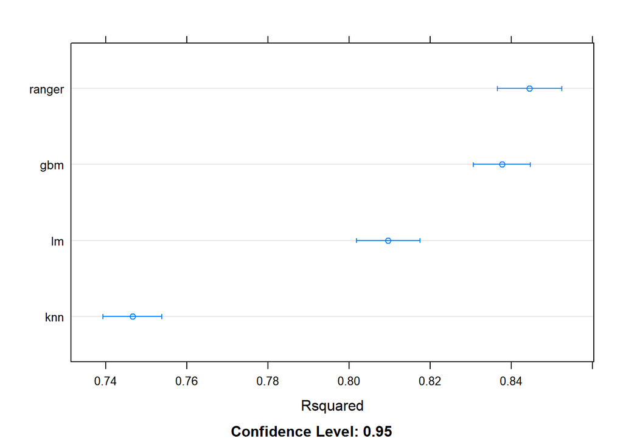

```r
# 95% C.I. for Rsquared of Each Model within Stack
set.seed(100)

resamples <- resamples(model_list_1)

dotplot(resamples, metric = "Rsquared")
```

```r
glm_ensemble_1 <- caretStack(
    model_list_1,                   # Models we trained above in caretList
    method="glm",                   # Use logistic regression to combine
    metric="Rsquared",              # Use Rsquared to measure quality of fit
    trControl=control
  )
summary(glm_ensemble_1)
```

```
##
## Call:
## NULL
##
## Deviance Residuals:
##      Min        1Q    Median        3Q       Max
## -1.60085  -0.09745   0.00954   0.11980   1.16750
##
## Coefficients:
##             Estimate Std. Error t value             Pr(>|t|)
## (Intercept) -0.59588    0.06212  -9.593 < 0.0000000000000002 ***
## gbm          0.32177    0.02969  10.837 < 0.0000000000000002 ***
## knn          0.05895    0.01430   4.122            0.0000378 ***
## ranger       0.59136    0.03047  19.405 < 0.0000000000000002 ***
## lm           0.07357    0.01990   3.696              0.00022 ***
## ---
## Signif. codes:  0 '***' 0.001 '**' 0.01 '*' 0.05 '.' 0.1 ' ' 1
##
## (Dispersion parameter for gaussian family taken to be 0.04523559)
##
##     Null deviance: 3116.16  on 10497  degrees of freedom
## Residual deviance:  474.66  on 10493  degrees of freedom
## AIC: -2701.4
##
## Number of Fisher Scoring iterations: 2
```

```r
# Predict the testing values
glm_test_pred_1 <- predict(glm_ensemble_1, test_data)
glm_test_pred_1 <- exp(glm_test_pred_1)

glm_results_1<-data.frame(  RMSE = RMSE(glm_test_pred_1, test_data$price),
                            Rsquare = R2(glm_test_pred_1, test_data$price))

glm_results_1
```

```
##       RMSE   Rsquare
## 1 191632.7 0.8816287
```

```r
# Predict prices for out of sample data the same way
predictions_oos_glm_1 <- predict(glm_ensemble_1,london_house_prices_2019_out_of_sample)
predictions_oos_glm_1 <- exp(predictions_oos_glm_1)

glm_pred_1<-data.frame(  RMSE = RMSE(predictions_oos_glm_1, london_house_prices_2019_out_of_sample$asking_price),
                            Rsquare = R2(predictions_oos_glm_1, london_house_prices_2019_out_of_sample$asking_price))

glm_pred_1
```

```
##       RMSE   Rsquare
## 1 295707.8 0.8336424
```

```r
# Model Comparison and Selection
library(dplyr)

# Create dataframe of all model's RMSE and Rsquared values on testing data
model_comparison_df_test <- rbind(lr_results, tree_results, knn_results, rf_results, gbm_results, glm_results_1)
names(model_comparison_df_test)[names(model_comparison_df_test) == "RMSE"] <- "RMSE_Test"
names(model_comparison_df_test)[names(model_comparison_df_test) == "Rsquare"] <- "Rsquare_Test"
model_comparison_df_test <- model_comparison_df_test %>%
  mutate(Model = c("Linear Regression", "Decision Tree", "K Nearest Neighbor", "Random Forest", "Gradient Boosting Machine", "Stacked Model"), .before = RMSE_Test)

# Create dataframe of all model's RMSE and Rsquared values on out of sample data
model_comparison_df_oos <- rbind(lr_pred, tree_pred, knn_pred, rf_pred, gbm_pred, glm_pred_1)
names(model_comparison_df_oos)[names(model_comparison_df_oos) == "RMSE"] <- "RMSE_OOS"
names(model_comparison_df_oos)[names(model_comparison_df_oos) == "Rsquare"] <- "Rsquare_OOS"
model_comparison_df_oos <- model_comparison_df_oos %>%
  mutate(Model = c("Linear Regression", "Decision Tree", "K Nearest Neighbor", "Random Forest", "Gradient Boosting Machine", "Stacked Model"), .before = RMSE_OOS)

# Combine above dataframes and create average RMSE and Rsquared metrics for each model
combined_model_comparison <- left_join(model_comparison_df_test, model_comparison_df_oos, by = 'Model')
combined_model_comparison <- combined_model_comparison %>%
  mutate(Average_RMSE = (RMSE_Test + RMSE_OOS)/2) %>%
  mutate(Average_Rsquare = (Rsquare_Test + Rsquare_OOS)/2)

combined_model_comparison
```

```
##                       Model RMSE_Test Rsquare_Test RMSE_OOS Rsquare_OOS
## 1         Linear Regression  273054.3    0.7554537 277399.0   0.8365919
## 2             Decision Tree  242886.2    0.7963774 353176.9   0.7570202
## 3        K Nearest Neighbor  273568.0    0.7942476 337737.7   0.8019112
## 4             Random Forest  213409.5    0.8740774 338038.9   0.8021586
## 5 Gradient Boosting Machine  214256.9    0.8557589 318024.4   0.8161633
## 6             Stacked Model  191632.7    0.8816287 295707.8   0.8336424
##   Average_RMSE Average_Rsquare
## 1     275226.6       0.7960228
## 2     298031.6       0.7766988
## 3     305652.9       0.7980794
## 4     275724.2       0.8381180
## 5     266140.6       0.8359611
## 6     243670.2       0.8576356
```

```r
# Select model with lowest average RMSE and highest average Rsquared
optimal_model <- combined_model_comparison[which(combined_model_comparison$Average_RMSE == min(combined_model_comparison$Average_RMSE) | combined_model_comparison$Average_Rsquare == max(combined_model_comparison$Average_Rsquare)),]

optimal_model
```

```
##           Model RMSE_Test Rsquare_Test RMSE_OOS Rsquare_OOS Average_RMSE
## 6 Stacked Model  191632.7    0.8816287 295707.8   0.8336424     243670.2
##   Average_Rsquare
## 6       0.8576356
```

# 8 Pick investments

In this section you should use the best algorithm you identified to choose 200 properties from the out of sample data.

```r
# Add predicted price column to OOS dataframe
out_of_sample_df <- london_house_prices_2019_out_of_sample

out_of_sample_df <- out_of_sample_df %>%
  mutate(predicted_price = predictions_oos_glm_1)
```

```r
# Add percentage price column to OOS dataframe
out_of_sample_df <- out_of_sample_df %>%
  mutate(percent_profit = ((predicted_price - asking_price)/asking_price)*100)
```

```r
# Re-order dataframe by percentage profit column
out_of_sample_df <- out_of_sample_df[order(-out_of_sample_df$percent_profit),]
```

```r
# Calculate Total Raw Profit from Chosen Investments
out_of_sample_df <- out_of_sample_df %>%
  mutate(raw_profit = predicted_price - asking_price)
```

```r
# Convert Total Raw Profit to Currency
total_raw_acq_cost <- as.data.frame(sum(out_of_sample_df$asking_price[1:200]))
names(total_raw_acq_cost)[names(total_raw_acq_cost) == "sum(out_of_sample_df$asking_price[1:200])"] <- "Price Value"

total_raw_revenue <- as.data.frame(sum(out_of_sample_df$predicted_price[1:200]))
names(total_raw_revenue)[names(total_raw_revenue) == "sum(out_of_sample_df$predicted_price[1:200])"] <- "Price Value"

total_raw_profit <- as.data.frame(sum(out_of_sample_df$raw_profit[1:200]))
names(total_raw_profit)[names(total_raw_profit) == "sum(out_of_sample_df$raw_profit[1:200])"] <- "Price Value"

acq_rev_profit <- rbind(total_raw_acq_cost, total_raw_revenue, total_raw_profit)

acq_rev_profit <- datatable(acq_rev_profit, rownames = c("Total Acquisition Cost", "Total Revenue", "Total Raw Profit"))
acq_rev_profit <- formatCurrency(acq_rev_profit, columns = "Price Value", currency = "£", interval = 3, mark = ",", digits = 2, before = TRUE)
acq_rev_profit
```

|  | Price Value |
| --- | --- |
| Total Acquisition Cost | 90669000 |
| Total Revenue | 139663725.482594 |
| Total Raw Profit | 48994725.4825936 |

```r
# Calculate Average Percent Profit from Chosen Investments
average_percent_profit <- mean(out_of_sample_df$percent_profit[1:200])
cat(average_percent_profit,"%")
```

```
## 63.63879 %
```

```r
# Create Raw Profit and Percent Profit Dataframes from Chosen Investments
inv_choices <- out_of_sample_df[1:200, ]

zone_1 <- inv_choices[inv_choices$london_zone == 1,]
zone_2 <- inv_choices[inv_choices$london_zone == 2,]
zone_3 <- inv_choices[inv_choices$london_zone == 3,]
zone_4 <- inv_choices[inv_choices$london_zone == 4,]
zone_5 <- inv_choices[inv_choices$london_zone == 5,]
zone_6 <- inv_choices[inv_choices$london_zone == 6,]

zone_1_raw_avg <- as.data.frame(mean(zone_1$raw_profit))
zone_2_raw_avg <- as.data.frame(mean(zone_2$raw_profit))
zone_3_raw_avg <- as.data.frame(mean(zone_3$raw_profit))
zone_4_raw_avg <- as.data.frame(mean(zone_4$raw_profit))
zone_5_raw_avg <- as.data.frame(mean(zone_5$raw_profit))
zone_6_raw_avg <- as.data.frame(mean(zone_6$raw_profit))

names(zone_1_raw_avg)[names(zone_1_raw_avg) == "mean(zone_1$raw_profit)"] <- "Raw_Profit"
names(zone_2_raw_avg)[names(zone_2_raw_avg) == "mean(zone_2$raw_profit)"] <- "Raw_Profit"
names(zone_3_raw_avg)[names(zone_3_raw_avg) == "mean(zone_3$raw_profit)"] <- "Raw_Profit"
names(zone_4_raw_avg)[names(zone_4_raw_avg) == "mean(zone_4$raw_profit)"] <- "Raw_Profit"
names(zone_5_raw_avg)[names(zone_5_raw_avg) == "mean(zone_5$raw_profit)"] <- "Raw_Profit"
names(zone_6_raw_avg)[names(zone_6_raw_avg) == "mean(zone_6$raw_profit)"] <- "Raw_Profit"

zone_1_raw_avg <- zone_1_raw_avg %>%
  mutate(Zone = "Zone 1", .before = Raw_Profit)
zone_2_raw_avg <- zone_2_raw_avg %>%
  mutate(Zone = "Zone 2", .before = Raw_Profit)
zone_3_raw_avg <- zone_3_raw_avg %>%
  mutate(Zone = "Zone 3", .before = Raw_Profit)
zone_4_raw_avg <- zone_4_raw_avg %>%
  mutate(Zone = "Zone 4", .before = Raw_Profit)
zone_5_raw_avg <- zone_5_raw_avg %>%
  mutate(Zone = "Zone 5", .before = Raw_Profit)
zone_6_raw_avg <- zone_6_raw_avg %>%
  mutate(Zone = "Zone 6", .before = Raw_Profit)

combined_zones_1 <- rbind(zone_1_raw_avg, zone_2_raw_avg, zone_3_raw_avg, zone_4_raw_avg, zone_5_raw_avg, zone_6_raw_avg)



zone_1_perc_avg <- as.data.frame(mean(zone_1$percent_profit))
zone_2_perc_avg <- as.data.frame(mean(zone_2$percent_profit))
zone_3_perc_avg <- as.data.frame(mean(zone_3$percent_profit))
zone_4_perc_avg <- as.data.frame(mean(zone_4$percent_profit))
zone_5_perc_avg <- as.data.frame(mean(zone_5$percent_profit))
zone_6_perc_avg <- as.data.frame(mean(zone_6$percent_profit))

names(zone_1_perc_avg)[names(zone_1_perc_avg) == "mean(zone_1$percent_profit)"] <- "Percent_Profit"
names(zone_2_perc_avg)[names(zone_2_perc_avg) == "mean(zone_2$percent_profit)"] <- "Percent_Profit"
names(zone_3_perc_avg)[names(zone_3_perc_avg) == "mean(zone_3$percent_profit)"] <- "Percent_Profit"
names(zone_4_perc_avg)[names(zone_4_perc_avg) == "mean(zone_4$percent_profit)"] <- "Percent_Profit"
names(zone_5_perc_avg)[names(zone_5_perc_avg) == "mean(zone_5$percent_profit)"] <- "Percent_Profit"
names(zone_6_perc_avg)[names(zone_6_perc_avg) == "mean(zone_6$percent_profit)"] <- "Percent_Profit"

zone_1_perc_avg <- zone_1_perc_avg %>%
  mutate(Zone = "Zone 1", .before = Percent_Profit)
zone_2_perc_avg <- zone_2_perc_avg %>%
  mutate(Zone = "Zone 2", .before = Percent_Profit)
zone_3_perc_avg <- zone_3_perc_avg %>%
  mutate(Zone = "Zone 3", .before = Percent_Profit)
zone_4_perc_avg <- zone_4_perc_avg %>%
  mutate(Zone = "Zone 4", .before = Percent_Profit)
zone_5_perc_avg <- zone_5_perc_avg %>%
  mutate(Zone = "Zone 5", .before = Percent_Profit)
zone_6_perc_avg <- zone_6_perc_avg %>%
  mutate(Zone = "Zone 6", .before = Percent_Profit)

combined_zones_2 <- rbind(zone_1_perc_avg, zone_2_perc_avg, zone_3_perc_avg, zone_4_perc_avg, zone_5_perc_avg, zone_6_perc_avg)
```

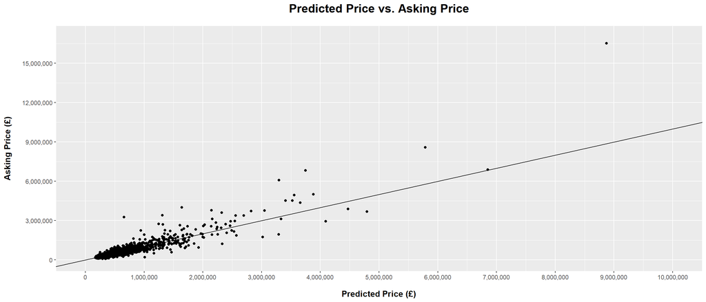

```r
# Plot of Predicted Price vs Asking Price
ggplot(out_of_sample_df, aes(x = predicted_price, y = asking_price)) +
  geom_point() +
  geom_abline(intercept=0, slope=1) +
  labs(x='Predicted Price (£)', y='Asking Price (£)', title='Predicted Price vs. Asking Price') +
  theme(axis.title.x = element_text(margin = margin(t = 14, r = 0, b = 0, l = 0))) +
  theme(axis.title.y = element_text(margin = margin(t = 0, r = 15, b = 0, l = 0))) +
  theme(plot.title = element_text(margin = margin(t = 0, r = 0, b = 16, l = 0))) +
  theme(plot.title = element_text(hjust = 0.5)) +
  theme(plot.title = element_text(face = "bold")) +
  theme(plot.title = element_text(size = 17)) +
  theme(axis.title.x = element_text(face = "bold")) +
  theme(axis.title.x = element_text(size = 12)) +
  theme(axis.title.y = element_text(face = "bold")) +
  theme(axis.title.y = element_text(size = 12)) +
  scale_x_continuous(breaks=seq(0,10000000,1000000), limits = c(0,10000000), labels = scales::comma) +
  scale_y_continuous(breaks=seq(0,15000000,3000000),limits = c(0,17000000), labels = scales::comma)
```

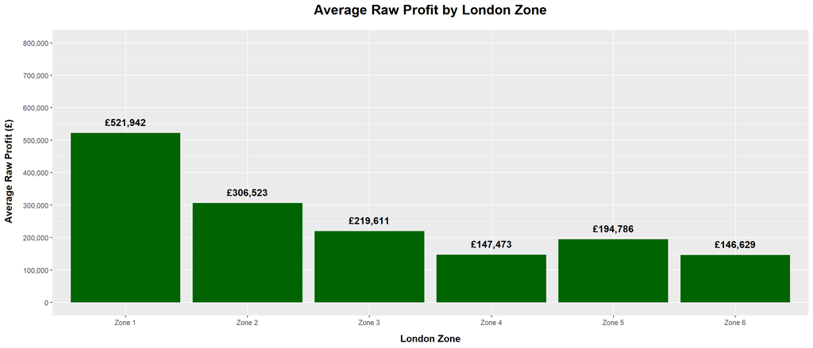

```r
library(scales)
# Plot of Average Raw Profits by London Zone
ggplot(combined_zones_1, aes(x = Zone, y = Raw_Profit)) +
  geom_bar(stat = 'identity', fill = 'darkgreen') +
    labs(title = "Average Raw Profit by London Zone",
                      x = "London Zone", y = " Average Raw Profit (£)") +
  theme(axis.title.x = element_text(margin = margin(t = 10, r = 0, b = 0, l = 0))) +
  theme(axis.title.y = element_text(margin = margin(t = 0, r = 12, b = 0, l = 0))) +
  theme(plot.title = element_text(margin = margin(t = 0, r = 0, b = 16, l = 0))) +
  theme(plot.title = element_text(hjust = 0.5)) +
  theme(plot.title = element_text(face = "bold")) +
  theme(plot.title = element_text(size = 17)) +
  theme(axis.title.x = element_text(face = "bold")) +
  theme(axis.title.x = element_text(size = 12)) +
  theme(axis.title.y = element_text(face = "bold")) +
  theme(axis.title.y = element_text(size = 12)) +
  scale_y_continuous(breaks=seq(0,800000,100000),limits = c(0,800000), labels = scales::comma) +
  geom_text(aes(label = paste0("£",comma(stat(y)))), stat = 'summary', fun = sum, vjust = -1, fontface='bold', size = 4.25)
```

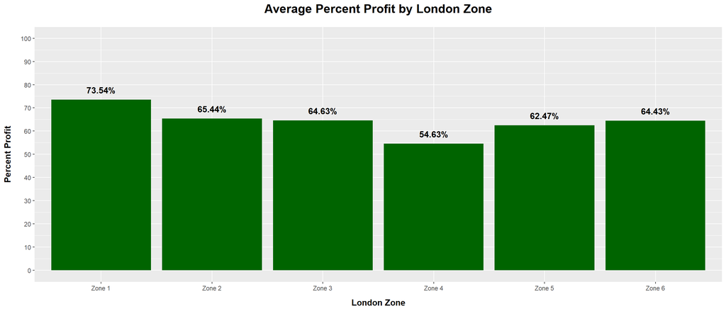

```r
# Plot of Average Percent Profits by London Zone
ggplot(combined_zones_2, aes(x = Zone, y = Percent_Profit)) +
  geom_bar(stat = 'identity', fill = 'darkgreen') +
    labs(title = "Average Percent Profit by London Zone",
                      x = "London Zone", y = "Percent Profit") +
  theme(axis.title.x = element_text(margin = margin(t = 10, r = 0, b = 0, l = 0))) +
  theme(axis.title.y = element_text(margin = margin(t = 0, r = 12, b = 0, l = 0))) +
  theme(plot.title = element_text(margin = margin(t = 0, r = 0, b = 16, l = 0))) +
  theme(plot.title = element_text(hjust = 0.5)) +
  theme(plot.title = element_text(face = "bold")) +
  theme(plot.title = element_text(size = 17)) +
  theme(axis.title.x = element_text(face = "bold")) +
  theme(axis.title.x = element_text(size = 12)) +
  theme(axis.title.y = element_text(face = "bold")) +
  theme(axis.title.y = element_text(size = 12)) +
  scale_y_continuous(breaks=seq(0,100,10),limits = c(0,100)) +
  geom_text(aes(label = paste0(round(stat(y), digits = 2),"%")), stat = 'summary', fun = sum, vjust = -1, fontface='bold', size = 4.25)
```

```r
# Create column to indicate selected investment properties
out_of_sample_df <- out_of_sample_df %>%
  mutate(buy = NA)

out_of_sample_df$buy[1:200] <- 1
out_of_sample_df$buy[201:1999] <- 0
```

```r
# Export final dataframe to CSV file
write.csv(out_of_sample_df, "C://Users//zerva//OneDrive//Documents//R Scipts LBS//am10.mam2022//zervaan_borok_AM04_project_2.csv")
```